# The music of Amon Tobin

Lucas de Visser

09/02/2021

# Introduction

The corpus I’m going to be inspecting is a collection of all albums from the electronic artist Amon Tobin. I chose this artist because he has produced a lot of different albums, ranging from dreamy ambient music (Fear in a Handful of Dust) to very intense beats (Fight! Fight! Fight!). There are interesting comparisons to be made in this corpus. Because his earliest album is from 1997, which is a relatively early year for electronic music, the change in music over time is an obvious comparison to make. Because the corpus consists of only albums, it is also interesting to see how and if albums differ, especially very similar albums like *Fear in a Handful of Dust* and *Long Stories*. I expect to find a lot of differences between the ambient albums and the heavier electronic albums, and I expect certain albums to be very difficult to differentiate. A strength of the corpus is that most of the music of Amon Tobin is represented in these albums. A weakness might be that certain albums might be too similar to find any meaningful differences. If expect *Fear in a Handful of Dust* and *Long Stories* to be too similar because they both use long dreamy chords and melodies without using drums, which might be difficult for Spotify to differentiate. An atypical track for this corpus might be ‘New York Editor’, for its jazzy drums and basslines.

Full albums used in the corpus:  
Bricolage (1997)  
Permutation (1998)  
Supermodified (2000)  
Out From Out Where (2002)  
Chaos Theory (2005)  
Foley Room (2007)  
ISAM (2011)  
Electronic Music for the Sydney Opera House (2017)  
Fear in a Handful of Dust (2019)  
Time To Run (2019)  
Long Stories (2019)  
Fight! Fight! Fight! (2020)  
The World As We Know It (2020)

# Graphs

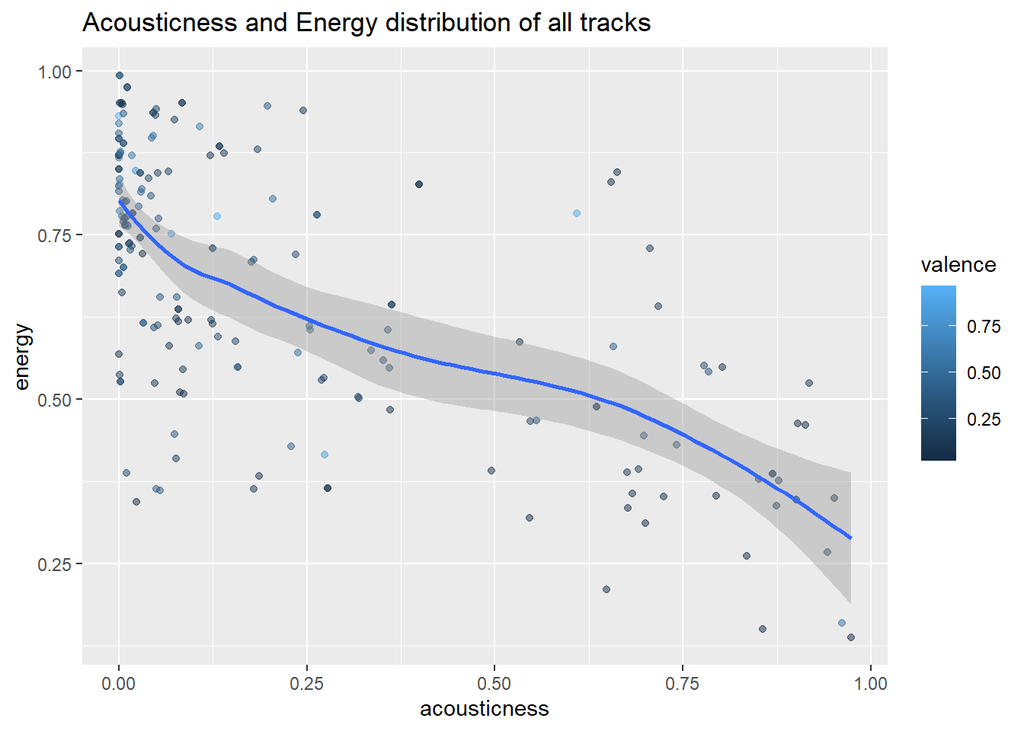

An interesting find here is that the more acoustic tracks tend to be less energetic than the less acoustic tracks according to Spotify, which is odd since acoustic albums like *Time To Run* feel much more energetic than mainly electronic albums like *Fear in a Handful of Dust*. Valence seems to be about evenly spread, but the few tracks with the lowest valence tend to have very low acousticness.

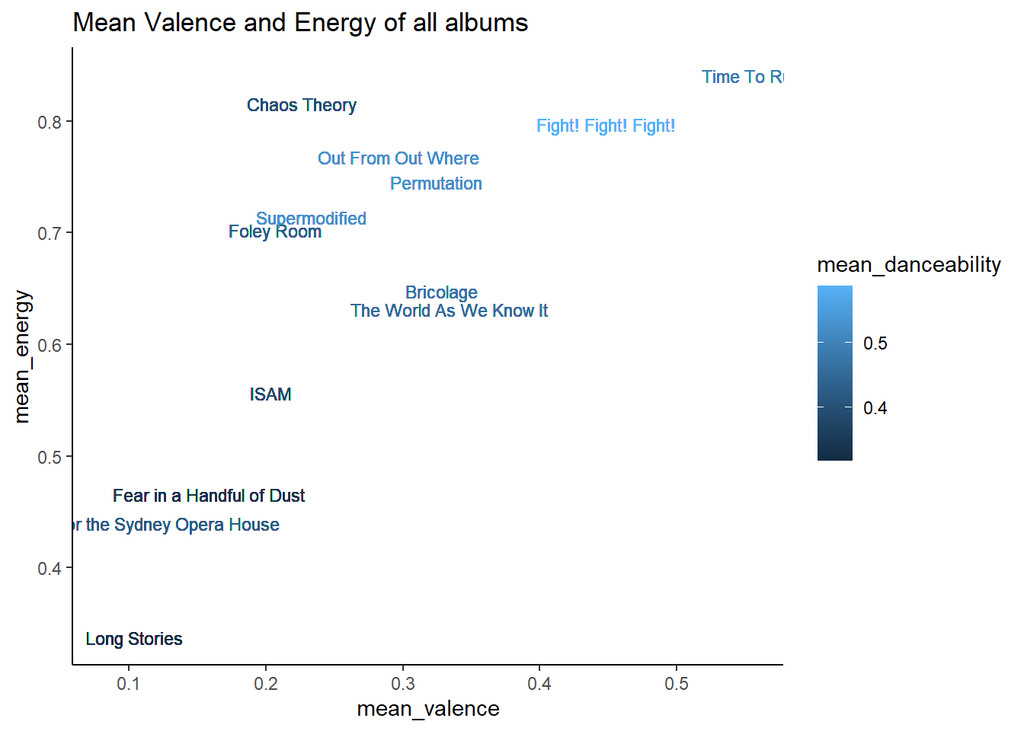

If you look at the mean valence and energy values of all albums, you can see a relationship between valence and energy between albums. The higher the valence, the higher the energy. It also looks like the more danceable albums are in the top right, high energy and high valence.

## Ignore the graphs below

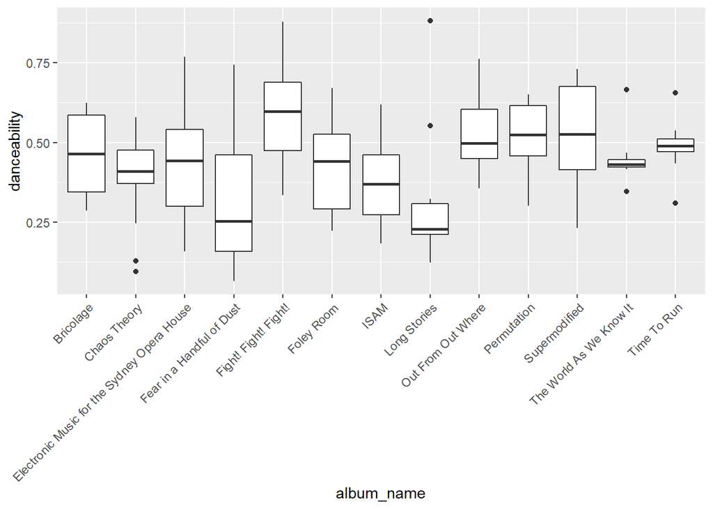

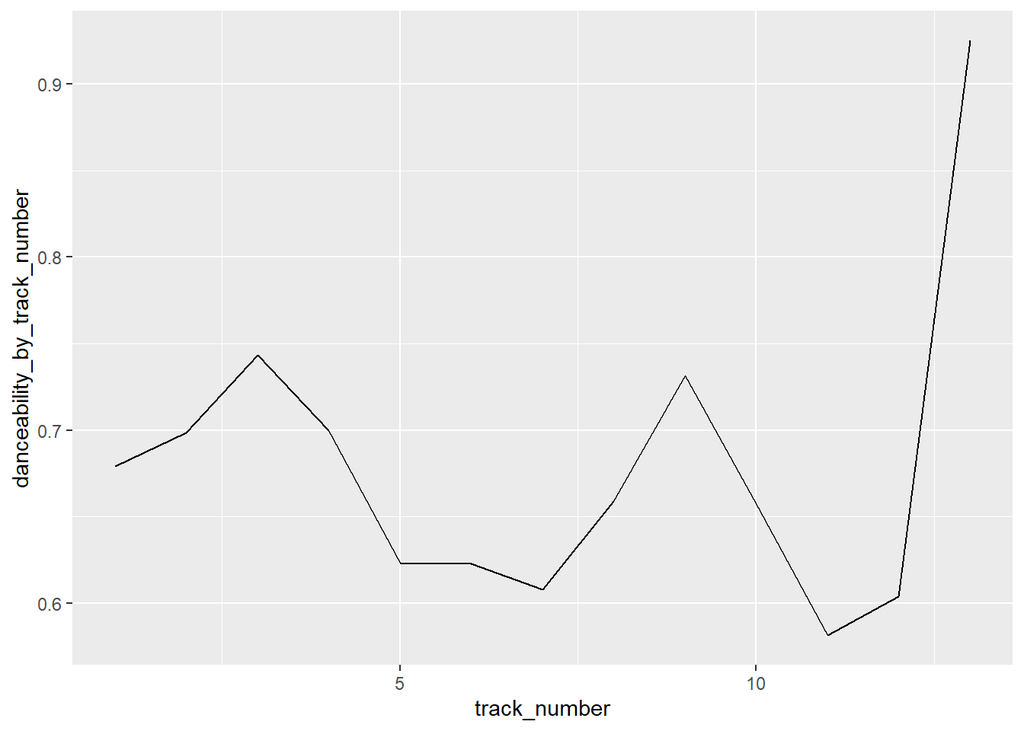

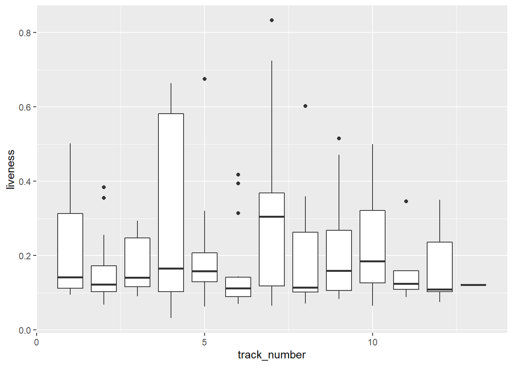